# Exercise 2_2: Basic Raster Operations

Introduction to Geospatial Techniques for Social Scientists in R

Author

Stefan Jünger & Dennis Abel

### Exercises

**🏋 Exercise 1**

Create a matrix with 8 rows and 8 columns filled with random numbers between 1 and 1000.

**💡 Tip**

You can create the numbers using the `sample()` function.

**🏋 Exercise 2**

Now, use this matrix to create a raster layer and plot it.

**💡 Tip**

The `terra::rast()` function can be fed with matrices to create a raster layer.

The `terra::rast()` function can not only be used to create raster data on the fly, but it is also quite dull. Instead, we can use it to import already prepared data.

**🏋 Exercise 3**

Import one of the raster `.tiff` files in the `./data` folder of the workshop directory.

**💡 Tip**

Make sure your file paths are set correctly. You can check them with `getwd()`. Setting is done with `setwd()`.

**🏋 Exercise 4**

Import the data on immigrants and inhabitants. Create a new layer showing the proportion of immigrants in each grid cell between 0 and 1. Next, apply z-standardization and dichotomize the data to get information about which grid cells deviate from the overall mean. Plot both “versions” of the data to see how they compare.

**💡 Tip**

You can handle raster layers as any simple data table using `+`, `-`, or `/` operators. Z-standardization can be applied using the `terra::scale()` function.

### Solutions

**✅ Solution 1**

```r
fancy_matrix <-
  sample(1:1000, 8*8, replace = TRUE) |>
  matrix(nrow = 8, ncol = 8)

fancy_matrix
```

```
     [,1] [,2] [,3] [,4] [,5] [,6] [,7] [,8]
[1,]  337  981  602  254  519   94  676  268
[2,]  194  140  862  952  931  221  990  461
[3,]   91  392  363  423  144  534  282  542
[4,]  903  453  145  735  831  573  251  269
[5,]  229   69  146  249  357  560  728  795
[6,]  832  227  998  557  539  729   16  912
[7,]  175  527  522  370  857  732  694  636
[8,]  813  454  538  642  311  318  505  303
```

**✅ Solution 2**

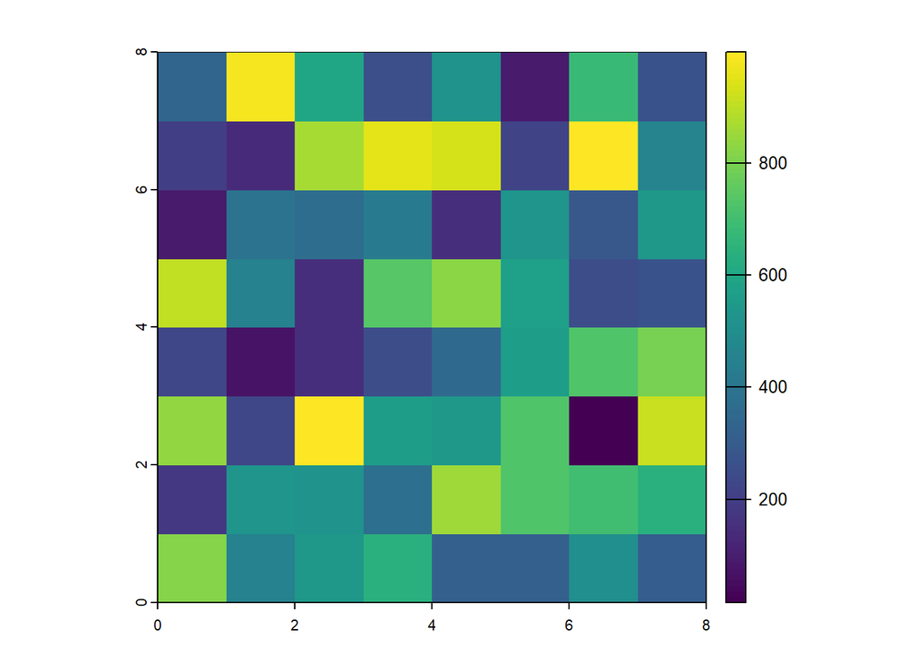

```r
library(terra)
fancy_raster_layer <- terra::rast(fancy_matrix)

terra::plot(fancy_raster_layer)
```

**✅ Solution 3**

```r
immigrants_cologne <- terra::rast("./data/immigrants_cologne.tif")
```

**✅ Solution 4**

```r
# load all layers
immigrants_cologne <- terra::rast("./data/immigrants_cologne.tif")

inhabitants_cologne <- terra::rast("./data/inhabitants_cologne.tif")

# create proportation layer
immigrants_proportion <- immigrants_cologne / inhabitants_cologne

# scale data
immigrants_proportion_scaled <- terra::scale(immigrants_proportion)

immigrants_proportion_scaled[immigrants_proportion_scaled < 0] <- 0
immigrants_proportion_scaled[immigrants_proportion_scaled > 0] <- 1

terra::plot(immigrants_proportion)

terra::plot(immigrants_proportion_scaled)
```

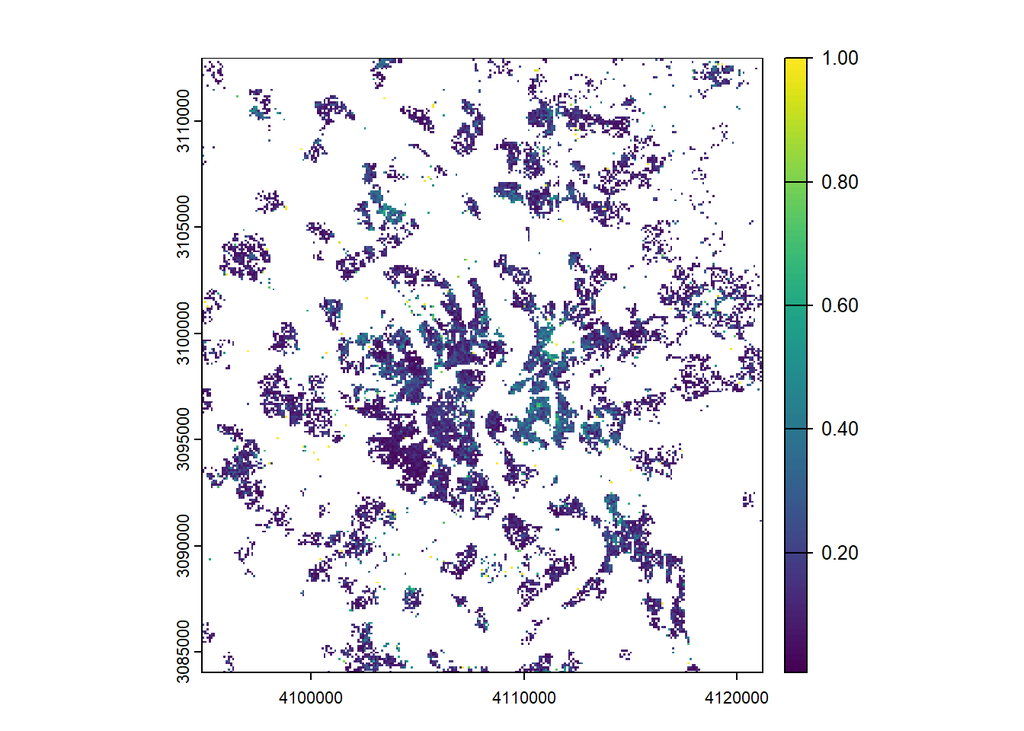

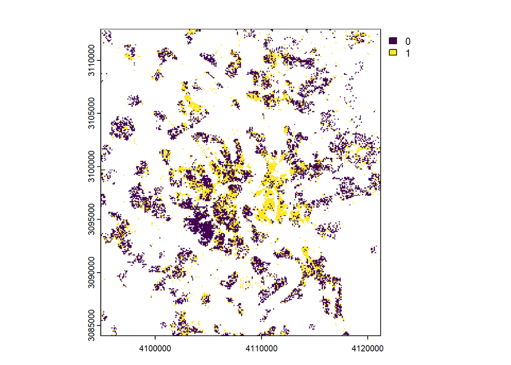